# HAR Data Analysis

Obi Isebor

Sunday, July 26, 2015

### Executive Summary

Given Human Activity Recognition (HAR) data, the goal of this project was to predict how subjects perform a weight-lifting exercise (Unilateral Dumbbell Biceps Curl), in a manner that corresponds to the specified execution of the exercise (class A) or in ways that correspond to 4 common mistakes (classes B - E).

Following the analysis presented in the next section, it was found that a prediction model based on Random Forests (RF) from the R caret package was sufficient to properly predict how subjects performed the weight-lifting exercise given the provided HAR training and test data. Training the prediction model takes quite a bit of time depending on the number of observations and variables so training and cross-validation were done with an increasing proportion of training observations until sufficient accuracy of the prediction model was obtained.

It was discovered that only 10% of the provided training set was required to train the RF model to over 98% out-of-sample accuracy (required 13 minutes to train) which was deemed sufficient for the purposes of the project. The classes of the 20 provided test cases were predicted correctly, validating the decision to use only a small but sufficient training set.

### Analysis

Assuming that both provided HAR training and test sets are in the current working directory, read in the large training and 20-case test data (note that blanks are treated the same as `NA`).

```r
library(ggplot2)
library(caret)
lt_data <- read.csv("pml-training.csv", na.strings=c("", "NA"))
test_data <- read.csv("pml-testing.csv", na.strings = c("","NA"))
```

We can observe that the large training data contains 19622 observations and 160 variables, the last of which is the `classe` variable we are interested in predicting.

A lot of columns have a significant proportion of `NA`’s so we opt to remove variables if more than 50% of their entries are `NA` .

```r
lt_data_reduced <- lt_data[, colSums(is.na(lt_data)) < nrow(lt_data) * 0.5]
test_data_reduced <- test_data[, colSums(is.na(test_data)) < nrow(test_data) * 0.5]
```

Now our number of variables has been decreased from 160 to 60. We can now go ahead and split our large training data set into a smaller training and testing subsets for cross validation. Note that we ignore the first variable which is just the index of the observations. Below, we first use a very small training proportion of 0.1%.

```r
inTrain <- createDataPartition(y=lt_data_reduced$classe, p =0.001, list=F)
training <- lt_data_reduced[ inTrain,-1]
testing  <- lt_data_reduced[-inTrain,-1]
```

Move forward with the training of the RF model, time it and perform cross-validation using the testing subset of the large training data. Note the output of time taken to perform training.

```r
set.seed(12345)
system.time(modelFit_rf1 <- train(classe ~ ., method="rf",data=training))
```

```
##    user  system elapsed
##    4.54    0.01    4.57
```

```r
confusionMatrix(testing$classe,predict(modelFit_rf1,testing))
```

```
## Confusion Matrix and Statistics
##
##           Reference
## Prediction    A    B    C    D    E
##          A 3607  249  703  217  798
##          B 1447  583  730  447  586
##          C 1346  305  957  366  444
##          D  662   81  723 1229  517
##          E 1047  268  532  857  899
##
## Overall Statistics
##
##                Accuracy : 0.3712
##                  95% CI : (0.3644, 0.378)
##     No Information Rate : 0.4137
##     P-Value [Acc > NIR] : 1
##
##                   Kappa : 0.1925
##  Mcnemar's Test P-Value : <2e-16
##
## Statistics by Class:
##
##                      Class: A Class: B Class: C Class: D Class: E
## Sensitivity            0.4448  0.39233  0.26255   0.3944  0.27713
## Specificity            0.8288  0.82279  0.84575   0.8797  0.83468
## Pos Pred Value         0.6471  0.15370  0.27999   0.3826  0.24951
## Neg Pred Value         0.6790  0.94287  0.83389   0.8849  0.85341
## Prevalence             0.4137  0.07582  0.18597   0.1590  0.16551
## Detection Rate         0.1840  0.02974  0.04883   0.0627  0.04587
## Detection Prevalence   0.2844  0.19352  0.17439   0.1639  0.18383
## Balanced Accuracy      0.6368  0.60756  0.55415   0.6371  0.55590
```

Note that the out-of-sample prediction accuracy is not very good (37.1%) when utilizing a training proportion of 0.1%. The corresponding prediction results on the provided HAR 20-case test set is as follows (these are mostly incorrect):

```r
pred4proj <- predict(modelFit_rf1,test_data_reduced[,-60])
pred4proj <- as.data.frame(pred4proj, test_data_reduced$problem_id  )
```

```r
pred4proj
```

```
##    pred4proj
## 1          E
## 2          A
## 3          C
## 4          C
## 5          A
## 6          C
## 7          A
## 8          C
## 9          A
## 10         C
## 11         B
## 12         B
## 13         E
## 14         C
## 15         D
## 16         E
## 17         A
## 18         C
## 19         A
## 20         E
```

By increasing the proportion of the provided HAR training data set that is actually used for training the RF model (i.e., `p` in the `createDataPartition` function above), we get better out-of-sample prediction accuracy from our model. The plot on the left of the figure below shows the resulting improvement in accuracy by increasing the proportion of the HAR training set used from 0.1% to 0.5% to 1% to 5% to 10%. The plot on the right shows the corresponding increase in training time (in seconds).

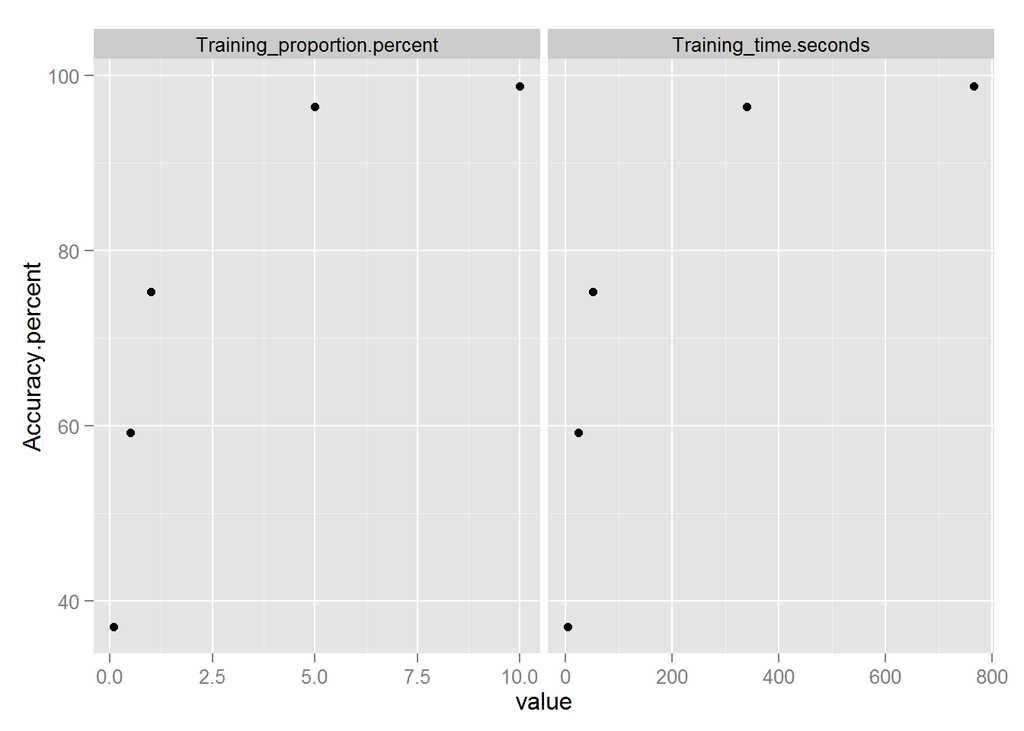

The plot on the left of the figure above illustrates the convergence achieved in prediction accuracy by increasing the training set size. The last value of 98.8% is deemed sufficient for this prediction problem and that model is used to predict on the 20-case test set. The corresponding predicted classes from the RF models built with varying training sizes are shown in the table below. Note the convergence of results in going from 5% to 10% proportion of large training set. The last column of results were submitted on Coursera for this project and were all correct.

```
##    prop_0.1 prop_0.5 prop_1.0 prop_5 prop_10
## 1         E        A        B      B       B
## 2         A        A        A      A       A
## 3         C        A        A      B       B
## 4         C        A        A      A       A
## 5         A        A        A      A       A
## 6         C        E        E      E       E
## 7         A        D        D      D       D
## 8         C        A        D      B       B
## 9         A        A        A      A       A
## 10        C        A        A      A       A
## 11        B        A        A      B       B
## 12        B        A        C      C       C
## 13        E        B        B      B       B
## 14        C        A        A      A       A
## 15        D        E        E      E       E
## 16        E        A        E      E       E
## 17        A        A        A      A       A
## 18        C        B        D      B       B
## 19        A        A        B      B       B
## 20        E        A        B      B       B
```